# Clase 02

```
Tibles, filtrar y agrupar:
dplyr, filter, arrange, select, mutate,
summarise, group_by, ungroup,
```

Una versión actualizada de este material en : [clase02](https://mar71n.github.io/rconr/apuntes2023/clase02.html)

```r
#install.packages("dplyr")
library(dplyr)
#install.packages("readr")
library(readr)
#install.packages("lubridate")
library(lubridate)
```

```r
#install.packages("ggplot2")
library(ggplot2)
```

### Datasets

#### Los individuales:

```r
eah2021_ind <- read_csv2("./datos/eah2021_bu_ampliada/eah2021_bu_ampliada_ind.txt")
```

```
## ℹ Using "','" as decimal and "'.'" as grouping mark. Use `read_delim()` for more control.
```

```r
eah2021_hog <- read_csv2("./datos/eah2021_bu_ampliada/eah2021_bu_ampliada_hog.txt")
```

```
## ℹ Using "','" as decimal and "'.'" as grouping mark. Use `read_delim()` for more control.
```

#### Una primera mirada, según lo que esperemos, por lo general alguno de estos:

#### [readr::spec](https://readr.tidyverse.org/reference/spec.html)

```r
spec(eah2021_ind)
head(eah2021_ind)
```

```
## # A tibble: 6 × 139
##      id nhogar miembro comuna dominio  edad  sexo parentes_2  p5_2  p6_a  p6_b
##   <dbl>  <dbl>   <dbl>  <dbl>   <dbl> <dbl> <dbl>      <dbl> <dbl> <dbl> <dbl>
## 1     1      1       1      5       4    18     1          1     6    95    95
## 2     1      1       2      5       4    16     2          7     6    95    95
## 3     2      1       1     14       4    18     2          1     6    95    95
## 4     3      1       1      2       4    18     2          1     6    95    95
## 5     4      1       1      4       3    18     1          1     1    95    95
## 6     4      1       2      4       3    16     2          2     1    95    95
## # ℹ 128 more variables: estado <dbl>, categori <dbl>, t1 <dbl>, t2 <dbl>,
## #   t3 <dbl>, t4 <dbl>, t5 <dbl>, t6 <dbl>, t7 <dbl>, t8 <dbl>, t9 <dbl>,
## #   t10 <dbl>, t11 <dbl>, t12 <dbl>, t13 <dbl>, t14 <dbl>, t15 <dbl>,
## #   t18 <dbl>, t19 <dbl>, t19_bis <dbl>, t28 <dbl>, t29 <dbl>, t29a <dbl>,
## #   t30 <dbl>, sem_hs <chr>, t33 <dbl>, t34 <dbl>, t35 <dbl>, t37_cod_2 <dbl>,
## #   t37_coda_2 <dbl>, t38 <dbl>, t39 <dbl>, t40a <dbl>, t40b <dbl>, t40 <dbl>,
## #   t41_cod_2 <dbl>, t47 <dbl>, t48 <dbl>, t49 <dbl>, t50a <dbl>, t50b <dbl>, …
```

```r
summary(eah2021_ind)
```

```
##        id           nhogar         miembro           comuna
##  Min.   :   1   Min.   :1.000   Min.   : 1.000   Min.   : 1.000
##  1st Qu.:1402   1st Qu.:1.000   1st Qu.: 1.000   1st Qu.: 4.000
##  Median :2447   Median :1.000   Median : 2.000   Median : 8.000
##  Mean   :2518   Mean   :1.005   Mean   : 2.114   Mean   : 7.513
##  3rd Qu.:3597   3rd Qu.:1.000   3rd Qu.: 3.000   3rd Qu.:11.000
##  Max.   :5322   Max.   :3.000   Max.   :13.000   Max.   :15.000
##     dominio           edad            sexo         parentes_2         p5_2
##  Min.   :3.000   Min.   :  0.0   Min.   :1.000   Min.   :1.000   Min.   :0.00
##  1st Qu.:4.000   1st Qu.: 21.0   1st Qu.:1.000   1st Qu.:1.000   1st Qu.:1.00
##  Median :4.000   Median : 38.0   Median :2.000   Median :2.000   Median :2.00
##  Mean   :3.872   Mean   : 39.1   Mean   :1.533   Mean   :2.167   Mean   :2.82
##  3rd Qu.:4.000   3rd Qu.: 57.0   3rd Qu.:2.000   3rd Qu.:3.000   3rd Qu.:6.00
##  Max.   :4.000   Max.   :104.0   Max.   :2.000   Max.   :9.000   Max.   :9.00
##       p6_a            p6_b            estado         categori
##  Min.   : 0.00   Min.   : 0.000   Min.   :1.000   Min.   :0.000
##  1st Qu.: 0.00   1st Qu.: 0.000   1st Qu.:1.000   1st Qu.:0.000
##  Median : 0.00   Median : 0.000   Median :1.000   Median :2.000
##  Mean   :11.68   Mean   : 4.204   Mean   :1.902   Mean   :1.432
##  3rd Qu.: 1.00   3rd Qu.: 1.000   3rd Qu.:3.000   3rd Qu.:3.000
##  Max.   :95.00   Max.   :95.000   Max.   :3.000   Max.   :4.000
##        t1              t2              t3               t4
##  Min.   :0.000   Min.   :0.000   Min.   :0.0000   Min.   :0.00000
##  1st Qu.:1.000   1st Qu.:0.000   1st Qu.:0.0000   1st Qu.:0.00000
##  Median :1.000   Median :0.000   Median :0.0000   Median :0.00000
##  Mean   :1.294   Mean   :0.785   Mean   :0.6473   Mean   :0.02386
##  3rd Qu.:2.000   3rd Qu.:2.000   3rd Qu.:1.0000   3rd Qu.:0.00000
##  Max.   :2.000   Max.   :2.000   Max.   :5.0000   Max.   :5.00000
##        t5                 t6                 t7               t8
##  Min.   :0.000000   Min.   :0.000000   Min.   :0.0000   Min.   :0.000000
##  1st Qu.:0.000000   1st Qu.:0.000000   1st Qu.:0.0000   1st Qu.:0.000000
##  Median :0.000000   Median :0.000000   Median :1.0000   Median :0.000000
##  Mean   :0.000544   Mean   :0.001321   Mean   :0.5131   Mean   :0.005518
##  3rd Qu.:0.000000   3rd Qu.:0.000000   3rd Qu.:1.0000   3rd Qu.:0.000000
##  Max.   :2.000000   Max.   :3.000000   Max.   :2.0000   Max.   :3.000000
##        t9              t10               t11              t12
##  Min.   :0.0000   Min.   :0.00000   Min.   :0.0000   Min.   :0.00000
##  1st Qu.:0.0000   1st Qu.:0.00000   1st Qu.:0.0000   1st Qu.:0.00000
##  Median :0.0000   Median :0.00000   Median :0.0000   Median :0.00000
##  Mean   :0.1393   Mean   :0.09318   Mean   :0.2003   Mean   :0.05044
```

[output cut: 190 more lines]

```
##  Max.   :2.00000   Max.   :2.00000   Max.   :2.00000   Max.   :2.0000
##      t50d_e            t50d_f            t51_d           t23_1_cod
##  Min.   :0.00000   Min.   :0.00000   Min.   :0.00000   Min.   :   0.0
##  1st Qu.:0.00000   1st Qu.:0.00000   1st Qu.:0.00000   1st Qu.:   0.0
##  Median :0.00000   Median :0.00000   Median :0.00000   Median :   0.0
##  Mean   :0.04787   Mean   :0.05704   Mean   :0.06302   Mean   : 218.6
##  3rd Qu.:0.00000   3rd Qu.:0.00000   3rd Qu.:0.00000   3rd Qu.:   0.0
##  Max.   :2.00000   Max.   :2.00000   Max.   :3.00000   Max.   :9999.0
##    t24_1_cod          fexp
##  Min.   :    0   Min.   :   7.0
##  1st Qu.:    0   1st Qu.: 132.0
##  Median :    0   Median : 211.0
##  Mean   : 1579   Mean   : 239.3
##  3rd Qu.:    0   3rd Qu.: 329.0
##  Max.   :99999   Max.   :1614.0
```

#### Filtros

#### con [*[*](https://www.rdocumentation.org/packages/base/versions/3.6.2/topics/Extract)

#### o con [*dplyr::filter*](https://dplyr.tidyverse.org/reference/filter.html)

##### Subconjunto de datos donde todas las condiciones son VERDADERAS.

- ```r
  x <- tribble(
    ~A, ~B, ~C,
    #--|--|---
    "a", "t", 1,
    "a", "b", 1,
    "b", "u", 2,
    "c", NA, 3,
    "c", "b", 3
  )

  x
  ```

  ```
  ## # A tibble: 5 × 3
  ##   A     B         C
  ##   <chr> <chr> <dbl>
  ## 1 a     t         1
  ## 2 a     b         1
  ## 3 b     u         2
  ## 4 c     <NA>      3
  ## 5 c     b         3
  ```

  ```r
  # Las dos condiciones son VERDADERAS
  x %>% filter(A == "a", B == "b")
  ```

  ```
  ## # A tibble: 1 × 3
  ##   A     B         C
  ##   <chr> <chr> <dbl>
  ## 1 a     b         1
  ```

  ```r
  # Equivalente a & (AND) con [
  x[x$A == "a" & x$B == "b",]
  ```

  ```
  ## # A tibble: 1 × 3
  ##   A     B         C
  ##   <chr> <chr> <dbl>
  ## 1 a     b         1
  ```

  ```r
  # Si la condicion es NA, el registro es excluido por filter (cosa esperable), pero no por [
  x$B == "t"
  ```

  ```
  ## [1]  TRUE FALSE FALSE    NA FALSE
  ```

  ```r
  x %>% filter(B == "t")
  ```

  ```
  ## # A tibble: 1 × 3
  ##   A     B         C
  ##   <chr> <chr> <dbl>
  ## 1 a     t         1
  ```

  ```r
  x[x$B == "t",]
  ```

  ```
  ## # A tibble: 2 × 3
  ##   A     B         C
  ##   <chr> <chr> <dbl>
  ## 1 a     t         1
  ## 2 <NA>  <NA>     NA
  ```

#### Podemos usar para construir las condiciones:

##### ==, >, <, >= …

##### &, |, !, xor()

##### is.na()

##### between(), near()

```r
eah2021_hog[eah2021_hog$v12 == 4,]
```

```
## # A tibble: 4 × 117
##      id nhogar comuna dominio  v2_2    v4   v12    h1    h2    h3 h36_1 h36_1x
##   <dbl>  <dbl>  <dbl>   <dbl> <dbl> <dbl> <dbl> <dbl> <dbl> <dbl> <dbl>  <dbl>
## 1    16      1      3       4    10     1     4     0     2     1     2      0
## 2  1128      1      9       3     1     1     4     0     3     1     2      0
## 3  1708      1      8       3     1     2     4     0     1     2     2      0
## 4  3335      1      7       3     9     1     4     0     2     1     2      0
## # ℹ 105 more variables: h36_2 <dbl>, h36_2x <dbl>, h36_3 <dbl>, h36_3x <dbl>,
## #   h36_4 <dbl>, h36_4x <dbl>, h36_5 <dbl>, h36_5x <dbl>, h36_6 <dbl>,
## #   h36_6x <dbl>, hacinam_2 <dbl>, tipoho <dbl>, i_estratos <dbl>,
## #   i_canastas <dbl>, i_pobreza <dbl>, ent_rea_pm <dbl>, hog_per_0a17 <dbl>,
## #   hog_per_6a17 <dbl>, hog_per_0a12 <dbl>, hog_per_3a5 <dbl>,
## #   hog_per_15a17 <dbl>, hog_per_3a17 <dbl>, hpm2 <dbl>, hpm3 <dbl>,
## #   hpm1 <dbl>, pm7 <dbl>, pm8 <dbl>, pm9 <dbl>, pm13 <dbl>, pm14 <dbl>, …
```

```r
eah2021_hog %>% filter(v12 == 4)
```

```
## # A tibble: 4 × 117
##      id nhogar comuna dominio  v2_2    v4   v12    h1    h2    h3 h36_1 h36_1x
##   <dbl>  <dbl>  <dbl>   <dbl> <dbl> <dbl> <dbl> <dbl> <dbl> <dbl> <dbl>  <dbl>
## 1    16      1      3       4    10     1     4     0     2     1     2      0
## 2  1128      1      9       3     1     1     4     0     3     1     2      0
## 3  1708      1      8       3     1     2     4     0     1     2     2      0
## 4  3335      1      7       3     9     1     4     0     2     1     2      0
## # ℹ 105 more variables: h36_2 <dbl>, h36_2x <dbl>, h36_3 <dbl>, h36_3x <dbl>,
## #   h36_4 <dbl>, h36_4x <dbl>, h36_5 <dbl>, h36_5x <dbl>, h36_6 <dbl>,
## #   h36_6x <dbl>, hacinam_2 <dbl>, tipoho <dbl>, i_estratos <dbl>,
## #   i_canastas <dbl>, i_pobreza <dbl>, ent_rea_pm <dbl>, hog_per_0a17 <dbl>,
## #   hog_per_6a17 <dbl>, hog_per_0a12 <dbl>, hog_per_3a5 <dbl>,
## #   hog_per_15a17 <dbl>, hog_per_3a17 <dbl>, hpm2 <dbl>, hpm3 <dbl>,
## #   hpm1 <dbl>, pm7 <dbl>, pm8 <dbl>, pm9 <dbl>, pm13 <dbl>, pm14 <dbl>, …
```

```r
eah2021_ind %>% filter(between(edad, 30, 35))
```

```
## # A tibble: 1,180 × 139
##       id nhogar miembro comuna dominio  edad  sexo parentes_2  p5_2  p6_a  p6_b
##    <dbl>  <dbl>   <dbl>  <dbl>   <dbl> <dbl> <dbl>      <dbl> <dbl> <dbl> <dbl>
##  1     5      1       2      9       4    33     2          6     3     0     0
##  2    42      1       2     13       4    30     1          2     1     0     0
##  3    64      1       3      4       4    30     1          7     1     0     0
##  4    66      1       2      7       4    31     2          2     2     0     0
##  5    99      1       2      3       4    35     1          8     6     0     0
##  6   132      1       2      5       4    31     2          2     1     0     0
##  7   157      1       2      2       4    34     1          2     1     0     0
##  8   187      1       6      7       3    31     1          2     1     0     0
##  9   190      1       2      1       4    35     2          2     2     0     0
## 10   194      1       2      2       4    32     1          7     6     0     0
## # ℹ 1,170 more rows
## # ℹ 128 more variables: estado <dbl>, categori <dbl>, t1 <dbl>, t2 <dbl>,
## #   t3 <dbl>, t4 <dbl>, t5 <dbl>, t6 <dbl>, t7 <dbl>, t8 <dbl>, t9 <dbl>,
## #   t10 <dbl>, t11 <dbl>, t12 <dbl>, t13 <dbl>, t14 <dbl>, t15 <dbl>,
## #   t18 <dbl>, t19 <dbl>, t19_bis <dbl>, t28 <dbl>, t29 <dbl>, t29a <dbl>,
## #   t30 <dbl>, sem_hs <chr>, t33 <dbl>, t34 <dbl>, t35 <dbl>, t37_cod_2 <dbl>,
## #   t37_coda_2 <dbl>, t38 <dbl>, t39 <dbl>, t40a <dbl>, t40b <dbl>, …
```

#### Frecuencias

##### Con [*base::table*](https://www.rdocumentation.org/packages/base/versions/3.6.2/topics/table)

```r
table(eah2021_ind$sexo)
```

```
##
##    1    2
## 6006 6862
```

```r
table(eah2021_ind$comuna)
```

```
##
##    1    2    3    4    5    6    7    8    9   10   11   12   13   14   15
## 1130  728  863 1295  704  715  976 1403  874  609  713  702  687  739  730
```

#### Al modo dplyr:

- [summarise](https://dplyr.tidyverse.org/reference/summarise.html) Resume cada grupo en menos filas.

  El resultado es una (o más) filas para cada combinación de variables de agrupación; si no hay variables de agrupación, la salida tendrá una sola fila que resuma todas las observaciones en la entrada. Contendrá una columna para cada variable de agrupación y una columna para cada una de las estadísticas de resumen que haya especificado. summarise() y summarize() son sinónimos.
- Funciones útiles
  - Centro: mean(), median()
  - Dispersión: sd(), IQR(), mad()
  - Rango: min(), max(), quantile()
  - Posición: first(), last(), nth()
  - Cuenta: n(), n_distinct()
  - Lógico: any(), all()

  ```r
  eah2021_ind %>% count(sexo)
  ```

  ```
  ## # A tibble: 2 × 2
  ##    sexo     n
  ##   <dbl> <int>
  ## 1     1  6006
  ## 2     2  6862
  ```

  ```r
  eah2021_ind %>% group_by(sexo) %>% summarise(n = n())
  ```

  ```
  ## # A tibble: 2 × 2
  ##    sexo     n
  ##   <dbl> <int>
  ## 1     1  6006
  ## 2     2  6862
  ```

- [group_by](https://dplyr.tidyverse.org/reference/group_by.html)

  group_by() toma un tbl existente y lo convierte en un tbl agrupado donde las operaciones se realizan “por grupo”. ungroup() elimina la agrupación.

  ```r
  #vacunas %>% group_by(GENERO) %>% summarise(mean(DOSIS_1))
  ```

- [count](https://dplyr.tidyverse.org/reference/count.html)

  *count()* le permite contar rápidamente los valores únicos de una o más variables: **df %>% count(a, b)** es aproximadamente *equivalente* a **df %>% group_by(a, b) %>% summarise(n = n() )**. *count()* está emparejado con tally(), un asistente de nivel inferior que es equivalente a df %>% summarise(n = n()).

  Pasamos un **wt** para ponderar, cambiando el resumen de n = n() a n = sum(wt).

  ```r
  eah2021_ind %>% count(sexo, wt = fexp)
  ```

  ```
  ## # A tibble: 2 × 2
  ##    sexo       n
  ##   <dbl>   <dbl>
  ## 1     1 1447532
  ## 2     2 1631407
  ```

  **count()** es una forma corta de hacer esto:

  ```r
  eah2021_ind %>% group_by(sexo) %>% summarise(n = sum(fexp))
  ```

  ```
  ## # A tibble: 2 × 2
  ##    sexo       n
  ##   <dbl>   <dbl>
  ## 1     1 1447532
  ## 2     2 1631407
  ```

#### Seleccionar columnas de interes, agregar columnas

##### [select()](https://dplyr.tidyverse.org/reference/select.html) y

##### [mutate()](https://dplyr.tidyverse.org/reference/mutate.html)

##### Crear, modificar y eliminar columnas.

##### **mutate()** agrega nuevas variables y conserva las existentes; Las nuevas variables sobrescriben las variables existentes del mismo nombre. Las variables se pueden eliminar estableciendo su valor en NULL

```r
eah2021_ind %>% select(sexo, edad, estado)
```

```
## # A tibble: 12,868 × 3
##     sexo  edad estado
##    <dbl> <dbl>  <dbl>
##  1     1    18      1
##  2     2    16      3
##  3     2    18      2
##  4     2    18      3
##  5     1    18      2
##  6     2    16      3
##  7     1     0      3
##  8     1    18      1
##  9     2    33      3
## 10     1    10      3
## # ℹ 12,858 more rows
```

```r
eah2021_ind %>% select(starts_with("i"))
```

```
## # A tibble: 12,868 × 20
##       id    i1    i4  i6_3   i10   i11 ioph_2 ioph_neto_2 ios_2 ioa_2 inglab_2
##    <dbl> <dbl> <dbl> <dbl> <dbl> <dbl>  <dbl>       <dbl> <dbl> <dbl>    <dbl>
##  1     1     1     0     2     0     0  20000       20000     0     0    20000
##  2     1     0     0     0     0     0      0           0     0     0        0
##  3     2     0     0     0     0     0      0           0     0     0        0
##  4     3     0     0     0     0     0      0           0     0     0        0
##  5     4     0     0     0     0     0      0           0     0     0        0
##  6     4     0     0     0     0     0      0           0     0     0        0
##  7     4     0     0     0     0     0      0           0     0     0        0
##  8     5     1     0     2     0     0  35000       35000     0     0    35000
##  9     5     0     0     0     0     0      0           0     0     0        0
## 10     5     0     0     0     0     0      0           0     0     0        0
## # ℹ 12,858 more rows
## # ℹ 9 more variables: i3_1x_2 <dbl>, i3_2x_2 <dbl>, i3_8x_2 <dbl>,
## #   i3_est_2 <dbl>, i3_otr_2 <dbl>, ingnolab_2 <dbl>, ingtot_2 <dbl>,
## #   itfb_2 <dbl>, ipcfb_2 <dbl>
```

```r
eah2021_ind %>%
  mutate(estado = factor(estado, levels= c(1:3), labels=c("Ocupado","Desocupado","Inactivo"))) %>%
  select(sexo, edad, estado)
```

```
## # A tibble: 12,868 × 3
##     sexo  edad estado
##    <dbl> <dbl> <fct>
##  1     1    18 Ocupado
##  2     2    16 Inactivo
##  3     2    18 Desocupado
##  4     2    18 Inactivo
##  5     1    18 Desocupado
##  6     2    16 Inactivo
##  7     1     0 Inactivo
##  8     1    18 Ocupado
##  9     2    33 Inactivo
## 10     1    10 Inactivo
## # ℹ 12,858 more rows
```

#### Ordenar

##### [dplyr::arrange()](https://dplyr.tidyverse.org/reference/arrange.html)

##### **arrange()** ordena las filas de un data frame por los valores de las columnas seleccionadas.

##### A diferencia de otros verbos dplyr, arrange() ignora en gran medida la agrupación; debe mencionar explícitamente las variables de agrupación (o usar .by_group = TRUE) para agruparlas. Las funciones se evaluan una vez para todos los datos, no por grupo.

##### Devuelve un data frame del mismo tipo que los datos de entrada.

- ```r
  x <- tribble(
    ~A, ~B, ~C,
    #--|--|---
    "a", "t", 1,
    "c", NA, 3,
    "b", "u", 2,
    "a", "b", 1,
    "c", "b", 3
  )

  x
  ```

  ```
  ## # A tibble: 5 × 3
  ##   A     B         C
  ##   <chr> <chr> <dbl>
  ## 1 a     t         1
  ## 2 c     <NA>      3
  ## 3 b     u         2
  ## 4 a     b         1
  ## 5 c     b         3
  ```

  ```r
  arrange(x, A)
  ```

  ```
  ## # A tibble: 5 × 3
  ##   A     B         C
  ##   <chr> <chr> <dbl>
  ## 1 a     t         1
  ## 2 a     b         1
  ## 3 b     u         2
  ## 4 c     <NA>      3
  ## 5 c     b         3
  ```

  ```r
  # Por ejemplo, las funciones de summarise se evaluan por grupo
  x %>% group_by(A) %>% summarise(sum(C))
  ```

  ```
  ## # A tibble: 3 × 2
  ##   A     `sum(C)`
  ##   <chr>    <dbl>
  ## 1 a            2
  ## 2 b            2
  ## 3 c            6
  ```

  ```r
  # arrange() no se evalua por grupo
  x %>% group_by(A, B) %>% arrange(A)
  ```

  ```
  ## # A tibble: 5 × 3
  ## # Groups:   A, B [5]
  ##   A     B         C
  ##   <chr> <chr> <dbl>
  ## 1 a     t         1
  ## 2 a     b         1
  ## 3 b     u         2
  ## 4 c     <NA>      3
  ## 5 c     b         3
  ```

  ```r
  # a menos que se indique con .by_group = TRUE
  x %>% group_by(A, B) %>% arrange(A, .by_group = TRUE)
  ```

  ```
  ## # A tibble: 5 × 3
  ## # Groups:   A, B [5]
  ##   A     B         C
  ##   <chr> <chr> <dbl>
  ## 1 a     b         1
  ## 2 a     t         1
  ## 3 b     u         2
  ## 4 c     b         3
  ## 5 c     <NA>      3
  ```

  ```r
  # La columna A ordenada
  sort(x$A)
  ```

  ```
  ## [1] "a" "a" "b" "c" "c"
  ```

  ```r
  # sort() no incluye los registros con NA
  sort(x$B)
  ```

  ```
  ## [1] "b" "b" "t" "u"
  ```

  ```r
  # arrange() ordena al final los NA
  arrange(x, B)
  ```

  ```
  ## # A tibble: 5 × 3
  ##   A     B         C
  ##   <chr> <chr> <dbl>
  ## 1 a     b         1
  ## 2 c     b         3
  ## 3 a     t         1
  ## 4 b     u         2
  ## 5 c     <NA>      3
  ```

  ```r
  # Se comporta igual que base::order()
  x[order(x$B),]
  ```

  ```
  ## # A tibble: 5 × 3
  ##   A     B         C
  ##   <chr> <chr> <dbl>
  ## 1 a     b         1
  ## 2 c     b         3
  ## 3 a     t         1
  ## 4 b     u         2
  ## 5 c     <NA>      3
  ```

##### [*options(…)*](https://www.rdocumentation.org/packages/base/versions/3.6.2/topics/options) nos permite ver y configurar opciones globales de R.

##### Entre ellas, *scipen*, con la que podemos controlar cuando usar notación cientifica.

##### *scipen*: Los valores positivos sesgan hacia la notación fija y los negativos hacia la notación científica: se preferirá la notación fija a menos que sea más que dígitos scipen más anchos.

##### Por defecto es cero.

```r
# guardo el valor actual
actual <- options("scipen")
# indico que use notación fija a menos que sean mas de 10 digitos:
options(scipen=10)
```

```r
# vuelvo a poner el valor anterior.
options(scipen=actual[[1]])
```

#### Un poco más de *ggplot*

##### *ggplot*, *aes*, *stat*, *position*, *facet*

```r
dfa <- data.frame(v1 = c("a","b","c","a"), v2 = c(2,5,2,1))
dfa
```

```
##   v1 v2
## 1  a  2
## 2  b  5
## 3  c  2
## 4  a  1
```

#### *geom_bar* por defecto solo requiere *aes(x)* y hace un counteo. *stat =“count”*

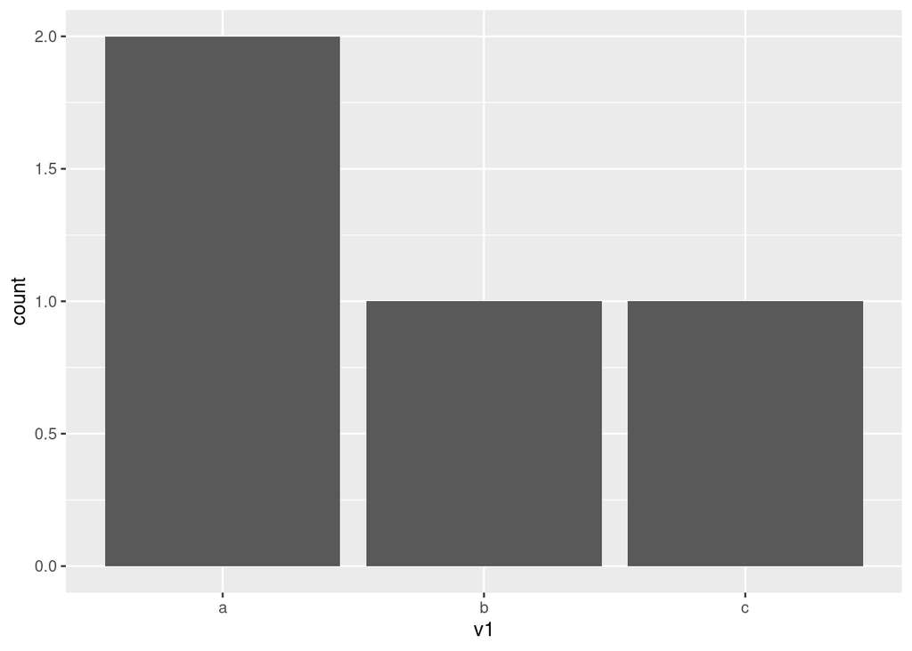

```r
ggplot(dfa, aes(v1)) +
  geom_bar()
```

##### El mismo gráfico con los valores por defecto explicitados:

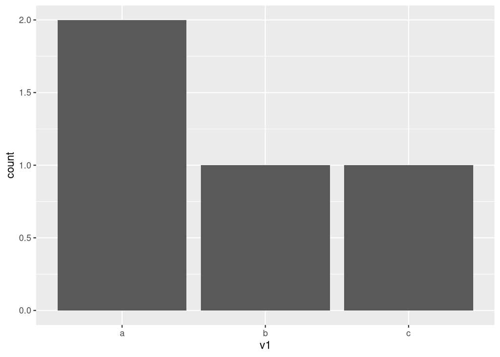

```r
ggplot(dfa, aes(v1)) +
  geom_bar(stat="count")
```

#### *geom_bar* con *stat = identity* agrupa por *x* ademas suma todos los casos

#### requiere *aes(x, y)*

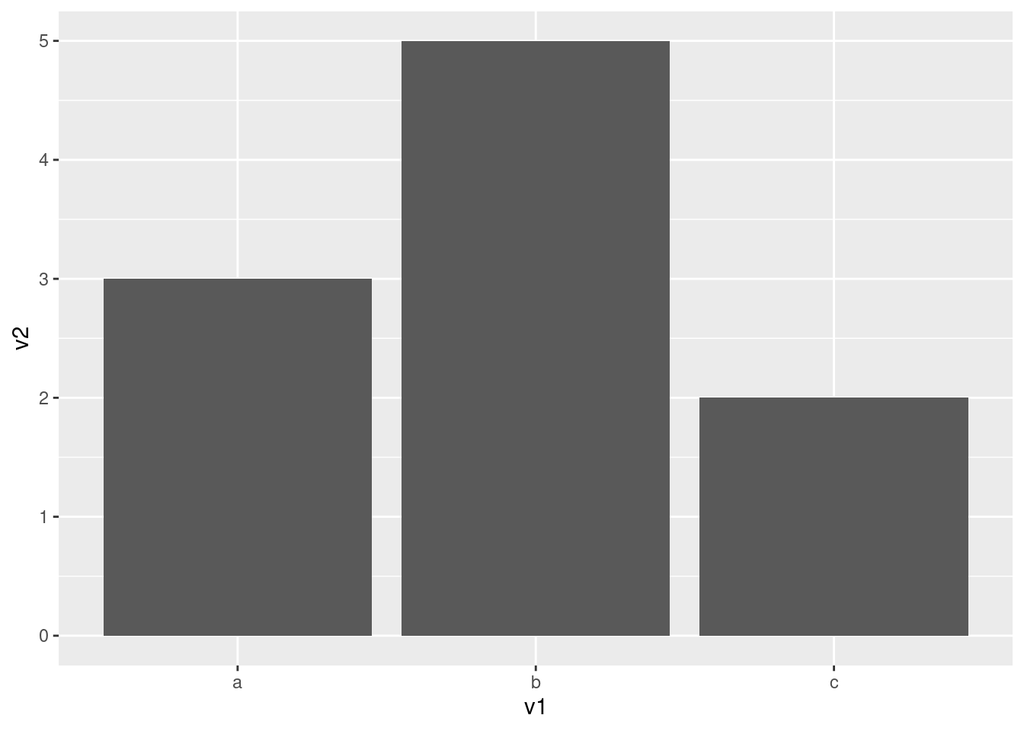

```r
ggplot(dfa, aes(v1, v2)) +
  geom_bar(stat="identity")
```

#### por defecto *position* es *“stack”*

```r
# el el grafico de arriba, algunos tienen tres columnas otros dos (donde no hay casos GENERO = N)
```

[output not shown]

[output not shown]

### Ejercicios

### Bibliografia:

#### [R para Ciencia de Datos - Cap 5 Transformación de datos](https://es.r4ds.hadley.nz/05-transform.html)

#### [Cheat Sheet *dplyr*](https://dplyr.tidyverse.org/index.html#cheat-sheet)

clase02.R

cuadro01.R

crear-cuadro-01.R